# DaliScope WorkedExample2 - HTML example output

DaliScope — WorkedExample2: HTML example output

Browse saved figures, tables and text without running code. This is an author-supplied export, originally named `WorkedExample-6.html`; its execution version was not recorded. This historical page was not regenerated for v0.1.9; its saved dom_FOLD count (6,708) differs from the current notebook run (6,465).

Python-backed controls require the notebook. Embedded 3D views depend on an external viewer and browser WebGL support.

```python
# Installs daliscope, all core requirements, and notebook extras (ipympl)
%pip install -e "..[notebook]" -q
#%pip install numba -q
#%pip install pydivsufsort -q
```

```python
import pandas as pd
from IPython.display import display

import daliscope
import daliscope.core.project
import daliscope.optics.histograms
import daliscope.analysis.data_preview
import daliscope.analysis.occupancy
import daliscope.analysis.structal_similarity # for cluster evaluation
import daliscope.widgets.pairwise_py3Dmol
import daliscope.optics.modules_sunburst
import daliscope.analysis.communities
import daliscope.analysis.pfam_stats

from daliscope.analysis.data_preview import show_heading
```

# Worked Example: Fish-Eye View of Fold Space Around a GOLD-like Domain with Jelly-Roll Topology

*Using DaliScope functions*

## Background

GOLD domains (Pfam clan CL0521) are small β-sandwich modules — eight strands arranged in two sheets, adopting a jelly-roll topology related to the Nucleoplasmin-like/VP fold — found across a functionally coherent family of proteins involved in Golgi trafficking. We use a representative GOLD-like domain as the query for this worked example: PDB entry 5TDQ, chain A, Golgi resident protein GCP60.

## Search strategy

Starting from this query, we searched AFDB2 using ISS-ProtSci with transitive closure, returning over 12,000 hits — far too many, and far too structurally heterogeneous, to inspect one at a time. As a first step, we modeled the *core* fold as a coherent set of secondary structural elements present across more than 5,000 of these hits, giving us a working definition of "the jelly-roll" independent of any single hit's idiosyncrasies.

## The fish-eye problem

A standard Dali search reports only one thing per hit: a Z-score, the structural similarity of that hit *to the query*. This is a radial measurement — it tells you how far each point sits from the center, but nothing about how the points relate to *each other*. The resulting picture is a fish-eye view: everything is placed relative to a single vantage point, and two hits that are highly similar to one another can appear on opposite sides of the query with no indication that they're related at all. This is a real limitation once a fold turns out — as this one does — to be shared across many distinct superfamilies: radial distance from the query cannot, by construction, distinguish "many independent instances of the same superfamily" from "several structurally distinct superfamilies that each merely resemble the query."

## Approach: the Rigid Core Pipeline

To move beyond this single-vantage-point view, we ran DaliScope's Rigid Core Pipeline: pairwise STRUCTAL rescoring among the hits themselves (not just against the query), followed by Infomap community detection on the resulting similarity network. This identifies communities of mutually similar sub-populations directly from the geometry of the hit set, with no reference to functional annotation. We then use Pfam classification, held out from the clustering itself, to ask whether these purely geometric communities are functionally coherent — and show that they are, with individual communities enriched for specific, related Pfam annotations.

## What this document covers

Working from this community structure, we:

- visualize the overall hit landscape and a Pfam-colored scatterplot of the search results;
- filter to the domain-relevant population and run the STRUCTAL/Infomap community analysis described above;
- summarize each community's characteristic Pfam annotations and free-text description stems.

# Raw Dali data

On loading the data, DaliScope presents a static scatterplot in the (Z-score, query-coverage) plane. These are the two main measures of alignment quality. They are generally correlated. The Dali-score is a sum over similarities of intramolecular distances - a more precise fit gives a higher Z-score with the same number of aligned residues.

The plot uses colour coding for

- sequence identity regimes
- Z-score regimes

Z-score regimes are based on heuristic thresholds - they usually work for "typical cases". Emprically, Dali Z-scores rank hits in reasonable agreement with expert-curated manual classifications like SCOP. However, the optimal classification thresholds differ from one query structure to another, depending on the shape and size of the protein.

Sequence identity regimes indicate what could be found by traditional sequence search (homologs), where structural alignment improves alignment quality (twilight) and where it is indispensable (dark).

Loading data

```
Pack loaded: 7622616 coord rows, 122647 segments, 12316 alignments, Query.pdb: yes
  Superimpositions: 12245/12245 succeeded
  Pfam: 12245/12245 alignments assigned
  Pfam domains: 11543/12245 targets
  Clan domains: 11543/12245 targets
  Pileups: 12245 sequ, 12245 dssp
Silver built: 12245 alignments (71 dropped), query length=123
✓ Registered 'dom_0-123': 12245 alignments
  Default view 'dom_0-123' registered
```

Top hits

|  | Target | Z-Score | RMSD | aln_len | Description | % Id |
| --- | --- | --- | --- | --- | --- | --- |
| 5 | e7w5A | 23.1 | 0.6 | 123 | HUMAN:AF-Q9H3P7-F1 GOLGI RESIDENT PROTEIN GCP60; | 98 |
| 3 | gfqjA | 22.9 | 0.6 | 123 | MOUSE:AF-Q8BMP6-F1 GOLGI RESIDENT PROTEIN GCP60; | 95 |
| 12 | ih11A | 22.3 | 0.6 | 123 | ONCVO/AFDB:AF-A0A044UH40-F1 Uncharacterized protein UNCHARACTERIZED PROTEIN; | 76 |

Creating filtered subsets

```
  Subset 'FILTERED_0': 11838/12245 rows
  Subset 'FILTERED_1': 3534/12245 rows
```

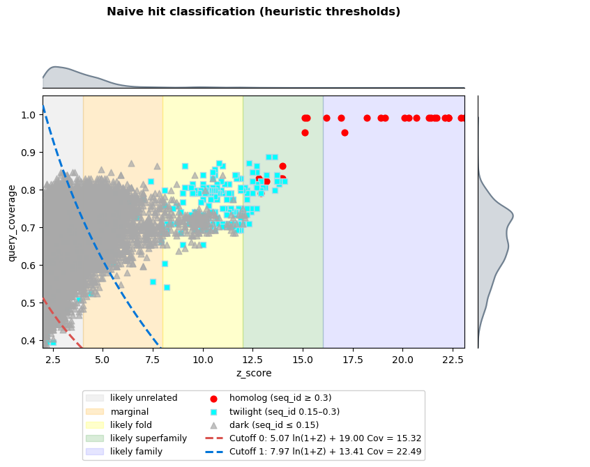

```python
# Load data
# The data pack must be uploaded to the Notebook host. Default data files are in DaliScope/notebooks/data.
pack_path = 'data/GOLD.tar.gz'

# 1. Initialize & Preview Top Hits
project, FULL_DF, FULL_VIEW = daliscope.analysis.data_preview.load_and_inspect_project(pack_path)

# 2. Plot Landscape
fig = daliscope.analysis.data_preview.plot_dali_hits_with_boundaries(
    FULL_DF,
    daliscope.analysis.data_preview.build_and_register_subsets(project, FULL_DF, FULL_VIEW)
)
```

> The plot shows a typical mix of sequence identity regimes: homologs have the highest Z-scores, followed by twilight hits. The large peak with dark hits can contain genuine biologically interesting hits, and noise.

> DaliScope automatically created two subsets wihch bisect the plane at valleys in the density distribution. Sometimes - but far from always - the subsets correspond to families or superfamilies. These automatically generated subsets are called FILTERED_0 and FILTERED_1.

# Structural coherence weighted alignment for rigid-body superimposition

Dali alignments optimize the similarity of intramolecular distances, which often results in high RMSD values. This is because far off CA atoms can be at the same radial distance from the common core, but occupy radically different spatial locations which destroy the rigid-body superimposition.We address this problem by weighted superimposition. Firstly, domain clipping gives zero weight to any atom pairs that were aligned by Dali but are outside the domain. Secondly, within the domain, positions are weighted by occupancy so that irregular loops, for exmaple, do not drive the superimposition.

The stacked alignment coloured by secondary structure (blue helices, red strands, green loops). Multidomain proteins typically display rectangular blocks corresponding to mobile modules.

We use this plot as a reference for defining domain boundaries: residues 23-123 form a coherent structural core. The "dom" view contains the clipped alignments and recomputed alignment metrics. We also generate a "dom_FOLD" subset, which consists of targets that cover at least 80& of the structural core.

dom_0-123 ( n = 12245 )

```
Initializing heavy assets...
Generating RGB Heatmap array...
```

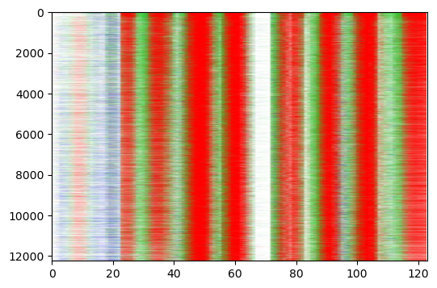

```
✓ Registered 'dom': 12245 alignments
  Subset 'dom_FOLD': 6708/12245 rows
```

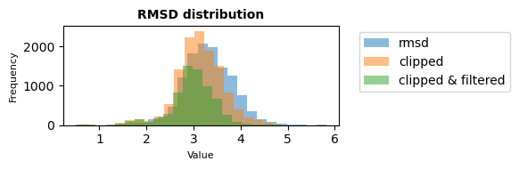

```python
# 3. Project structural alignments onto Query positions
project.viz.plot_msa(FULL_VIEW, 0, 123, plot_type='heatmap', data_col='dssp_pileup')

# 2. Register clipped parent domain. Updates superimpositions and alignment metrics (except Z-score which stays global)
daliscope.mechanics.metrics.register_multiple_domains(domain_string="23-123", project=project, custom_name="dom")

# 3. Register filtered FOLD subset.
daliscope.analysis.occupancy.create_fold_subset(project, 'dom', show_plot=False, cutoff=0.8)

# 4. Compare rmsd in raw Dali data, after domain clipping, and after FOLD ocuupancy thresholding
df = FULL_DF[['target_id','rmsd']].copy()
df['clipped & filtered'] = project.views['dom_FOLD']['rmsd']
df['clipped'] = project.views['dom']['rmsd']
daliscope.optics.histograms.plot_overlaid_distributions(
    [df['rmsd'], df['clipped'], df['clipped & filtered']],
    figsize=(6,2),
    title='RMSD distribution'
)
```

# Play with the structures

The Query structure is blue, the target is red. Thick lines and dashed lines show the raw Dali alignment, but the least-quares superimposition is based on the clipped and weighted equivalences.

```python
daliscope.widgets.pairwise_py3Dmol.generate_superimposition_view(
    target_ix=2777,
    df=project.views['dom_FOLD'],
    project=project,
    q_ca_coords=project.query_ca_coords,
    target_ca_coords=project.coords,
)
```

[Rendered Structure Target IX: 2777] **ID:** ej3hA | **Align ID:** 395  
**Z-score:** 4.40 | **RMSD:** 3.77 Å | **Len:** 85 | **SeqID:** 9.4%  
*DROME:AF-Q9VA69-F1 PROCOLLAGEN-PROLINE 4-DIOXYGENASE;*

3Dmol.js failed to load for some reason. Please check your browser console for error messages.

```
<py3Dmol.view at 0x7f0fe6a881d0>
```

# What do existing domain classifications tell us?

Here, we show the Pfam family and superfamily (clan) assignments of the domain-fold populations.

The table links family and clan identifiers to InterPro documentation. The clan descriptions confirm that these populations include jellyroll folds, a common structural topology.

A notable fraction of the targets lack Pfam assignments despite structural similarity to the domain fold, with approximately one thousand targets in the “Unassigned” category. Such gaps in domain classification occur even among targets with high Z-scores. In the domain cartoons, these targets appear as empty dashed red boxes; in the scatterplot, they appear as green dots dispersed among known GOLD-like domains (CL051).

These gaps in domain classification motivate a complementary question: **what structural communities exist within the domain-fold population, independent of sequence or existing annotation?**

```python
# 1. Table view
daliscope.analysis.pfam_stats.pfam_counts('dom_FOLD', project, k=10, print_tables = True)
```

```
Largest families in dom_FOLD population
```

| pfam | count | clan | clan_short | short | name |
| --- | --- | --- | --- | --- | --- |
| Unassigned | 1097 | NaN | NaN | NaN | NaN |
| [PF00622](https://www.ebi.ac.uk/interpro/entry/pfam/PF00622/) | 590 | [CL0004](https://www.ebi.ac.uk/interpro/set/pfam/CL0004/) | Concanavalin | SPRY | SPRY domain |
| [PF00431](https://www.ebi.ac.uk/interpro/entry/pfam/PF00431/) | 275 | [CL0164](https://www.ebi.ac.uk/interpro/set/pfam/CL0164/) | CUB | CUB | CUB domain |
| [PF01105](https://www.ebi.ac.uk/interpro/entry/pfam/PF01105/) | 264 | [CL0521](https://www.ebi.ac.uk/interpro/set/pfam/CL0521/) | GOLD-like | EMP24_GP25L | emp24/gp25L/p24 family/GOLD |
| [PF13640](https://www.ebi.ac.uk/interpro/entry/pfam/PF13640/) | 239 | [CL0029](https://www.ebi.ac.uk/interpro/set/pfam/CL0029/) | Cupin | 2OG-FeII_Oxy_3 | 2OG-Fe(II) oxygenase superfamily |
| [PF12819](https://www.ebi.ac.uk/interpro/entry/pfam/PF12819/) | 235 | [CL0202](https://www.ebi.ac.uk/interpro/set/pfam/CL0202/) | GBD | Malectin_like | Malectin-like domain |
| [PF00722](https://www.ebi.ac.uk/interpro/entry/pfam/PF00722/) | 195 | [CL0004](https://www.ebi.ac.uk/interpro/set/pfam/CL0004/) | Concanavalin | Glyco_hydro_16 | Glycosyl hydrolases family 16 |
| [PF00139](https://www.ebi.ac.uk/interpro/entry/pfam/PF00139/) | 182 | [CL0004](https://www.ebi.ac.uk/interpro/set/pfam/CL0004/) | Concanavalin | Lectin_legB | Legume lectin domain |
| [PF00648](https://www.ebi.ac.uk/interpro/entry/pfam/PF00648/) | 158 | [CL0125](https://www.ebi.ac.uk/interpro/set/pfam/CL0125/) | Peptidase_CA | Peptidase_C2 | Calpain family cysteine protease |
| [PF00386](https://www.ebi.ac.uk/interpro/entry/pfam/PF00386/) | 122 | [CL0100](https://www.ebi.ac.uk/interpro/set/pfam/CL0100/) | C1q_TNF | C1q | C1q domain |

```
Largest superfamilies in dom_FOLD population
```

| clan | count | clan_short |
| --- | --- | --- |
| [CL0004](https://www.ebi.ac.uk/interpro/set/pfam/CL0004/) | 1553 | Concanavalin |
| [CL0202](https://www.ebi.ac.uk/interpro/set/pfam/CL0202/) | 1532 | GBD |
| Unassigned | 1097 | NaN |
| [CL0029](https://www.ebi.ac.uk/interpro/set/pfam/CL0029/) | 793 | Cupin |
| [CL0521](https://www.ebi.ac.uk/interpro/set/pfam/CL0521/) | 403 | GOLD-like |
| [CL0164](https://www.ebi.ac.uk/interpro/set/pfam/CL0164/) | 296 | CUB |
| [CL0100](https://www.ebi.ac.uk/interpro/set/pfam/CL0100/) | 175 | C1q_TNF |
| [CL0125](https://www.ebi.ac.uk/interpro/set/pfam/CL0125/) | 158 | Peptidase_CA |
| [CL0055](https://www.ebi.ac.uk/interpro/set/pfam/CL0055/) | 118 | Nucleoplasmin |
| PF05986 | 50 | NaN |

dom_FOLD

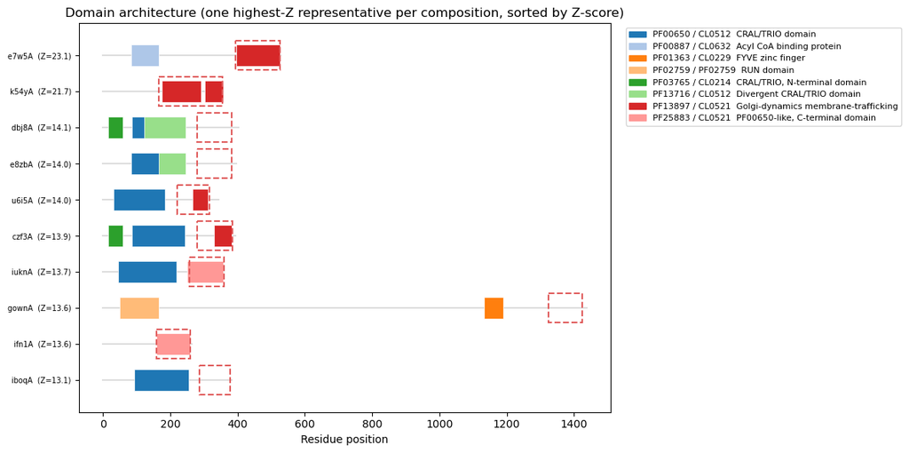

```python
# 2. Domain architecture cartoons
project.viz.architecture('dom_FOLD', renderer='matplotlib', pfam_col='pfam_domains')
```

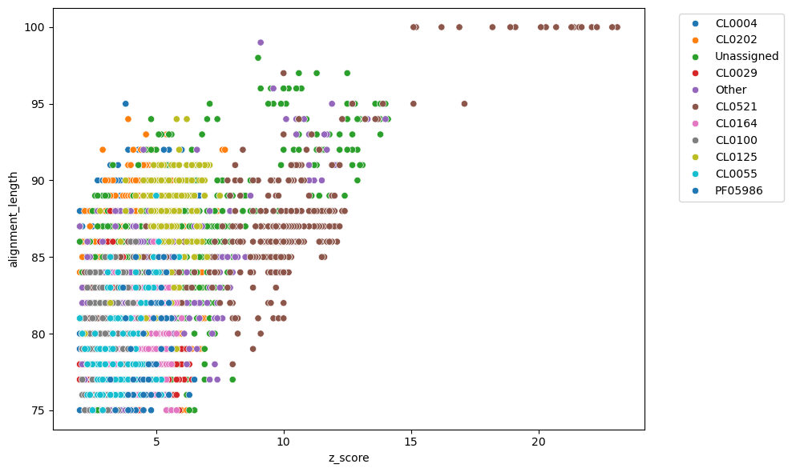

```python
# 3. Scatterplot colored by Pfam categories
df = project.views['dom_FOLD'][['alignment_length', 'z_score', 'clan', 'pfam']].copy()

#df["pfam_label"] = daliscope.analysis.pfam_stats.top_category_label(df, "pfam", k=10)
df["clan_label"] = daliscope.analysis.pfam_stats.top_category_label(df, "clan", k=10)

daliscope.optics.histograms.plot_scatter(df, x='z_score', y='alignment_length', color='clan_label', engine='matplot',)
```

# Community detection

```
Running build_structural_fingerprint_index ...
Running 1341600 pairwise STRUCTAL alignments ...
Estimated throughput: one million pairs per minute
Timings (sec): Index=1.00s, Alignment=73.34s, Graph=0.35s | Total=74.70s
  Subset 'dom_FOLD_module_1': 339/6708 rows
  Subset 'dom_FOLD_module_2': 965/6708 rows
  Subset 'dom_FOLD_module_3': 742/6708 rows
  Subset 'dom_FOLD_module_4': 293/6708 rows
  Subset 'dom_FOLD_module_5': 521/6708 rows
  Subset 'dom_FOLD_module_6': 603/6708 rows
  Subset 'dom_FOLD_module_7': 339/6708 rows
  Subset 'dom_FOLD_module_8': 87/6708 rows
  Subset 'dom_FOLD_module_9': 494/6708 rows
  Subset 'dom_FOLD_module_10': 131/6708 rows
  Subset 'dom_FOLD_module_11': 277/6708 rows
  Subset 'dom_FOLD_module_12': 190/6708 rows
  Subset 'dom_FOLD_module_13': 672/6708 rows
  Subset 'dom_FOLD_module_14': 97/6708 rows
  Subset 'dom_FOLD_module_15': 64/6708 rows
  Subset 'dom_FOLD_module_16': 57/6708 rows
  Subset 'dom_FOLD_module_17': 242/6708 rows
  Subset 'dom_FOLD_module_18': 306/6708 rows
  Subset 'dom_FOLD_module_19': 80/6708 rows
  Subset 'dom_FOLD_module_20': 85/6708 rows
  Subset 'dom_FOLD_module_21': 22/6708 rows
  Subset 'dom_FOLD_module_22': 67/6708 rows
  Subset 'dom_FOLD_module_23': 35/6708 rows
Successfully generated 23 module subsets in project.views.
```

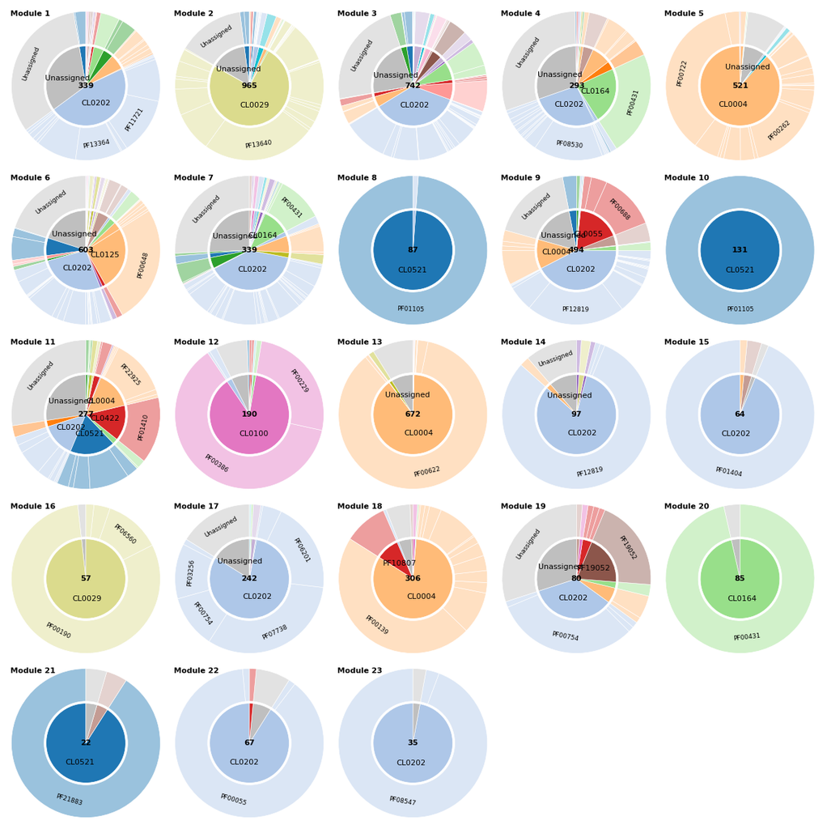

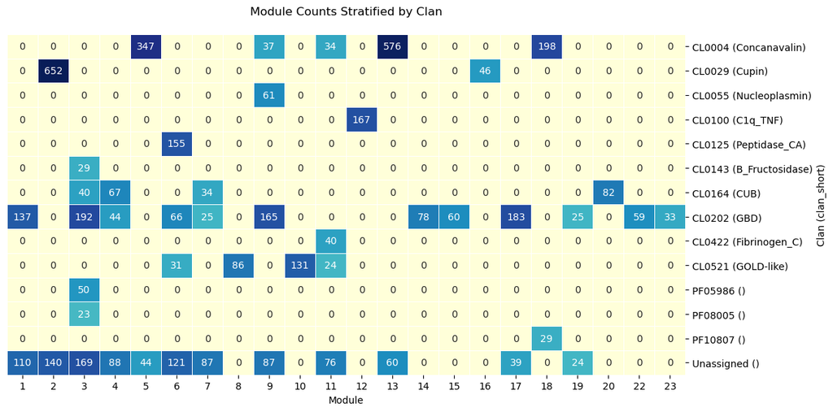

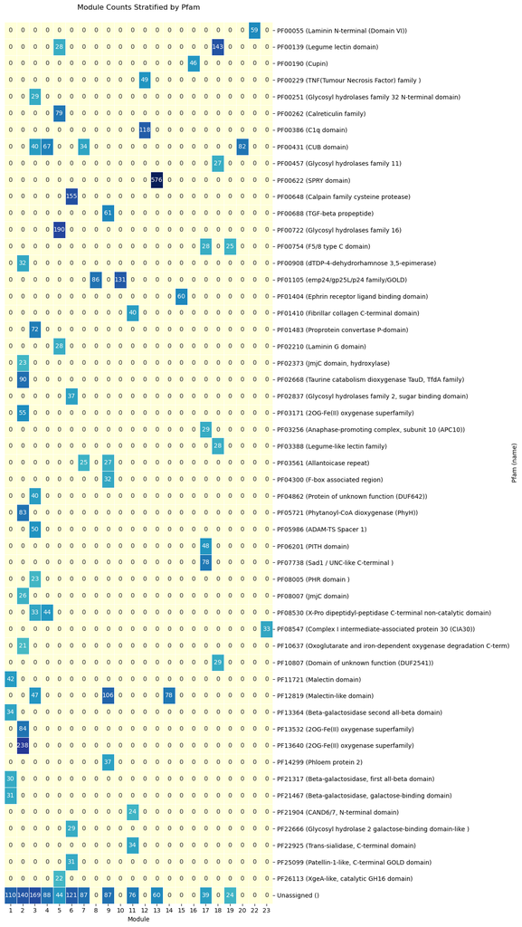

```python
# Run Rigid Core Pipeline

# Call community detection function across dom_FOLD
modules_df, n_modules = daliscope.analysis.communities.run_community_detection(
    view_name="dom_FOLD",
    domain_range=(23, 123),
    project=project,
    k_neighbors=200,
    max_workers=1,
    verbose=True,
)

# Sunburst diagrams. Colors are recycled after 18 clans
fig, axes, clan_colors = daliscope.optics.modules_sunburst.plot_module_sunbursts(
    modules_df,
    modules=range(1, n_modules+1),
)

# Cross-tabulating pfam catefories and modules
daliscope.analysis.communities.module_pfam_table(project, modules_df, row_group='clan', min_count=20)
daliscope.analysis.communities.module_pfam_table(project, modules_df, row_group='pfam', min_count=20)
```

## Recursive splitting

To test whether a module represents a single cohesive fold or a composite of finer structural sub-types, we apply community detection recursively to isolated module subsets. This approach reveals two distinct structural behaviors:

- dom_FOLD_module_12 (Monolithic Module): The structural network remains indivisible, confirming a single, tightly conserved structural core. This structural cohesion makes the unassigned targets strong candidates for unification with CL0100 (C1q_TNF).
- dom_FOLD_module_13 (Composite Module): The internal alignment network splits into distinct sub-clusters that cleanly partition along Pfam functional categories. Recursive analysis isolates PF17065 (a putative cytokine) as structurally distinct from CL0004 (Concanavalin), resolving hidden substructure that was masked at the global level.

dom_FOLD_module_12

```
Running build_structural_fingerprint_index ...
Running 38000 pairwise STRUCTAL alignments ...
Estimated throughput: one million pairs per minute
Timings (sec): Index=0.02s, Alignment=0.10s, Graph=0.01s | Total=0.13s
  Subset 'dom_FOLD_module_12_module_1': 190/190 rows
Successfully generated 1 module subsets in project.views.
```

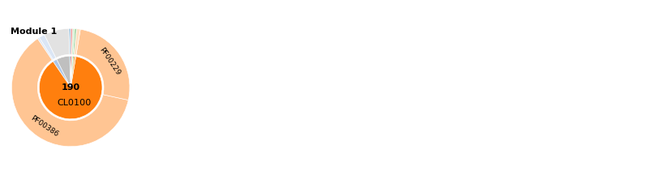

```python
show_heading("dom_FOLD_module_12")
daliscope.optics.modules_sunburst.module_recursion(project, 12)
```

dom_FOLD_module_13

```
Running build_structural_fingerprint_index ...
Running 134400 pairwise STRUCTAL alignments ...
Estimated throughput: one million pairs per minute
Timings (sec): Index=0.09s, Alignment=1.34s, Graph=0.03s | Total=1.46s
  Subset 'dom_FOLD_module_13_module_1': 259/672 rows
  Subset 'dom_FOLD_module_13_module_2': 8/672 rows
  Subset 'dom_FOLD_module_13_module_3': 235/672 rows
  Subset 'dom_FOLD_module_13_module_4': 170/672 rows
Successfully generated 4 module subsets in project.views.
```

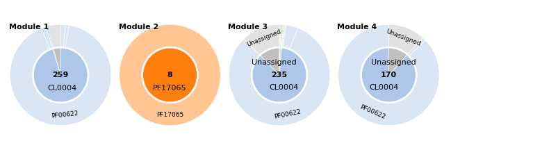

```python
show_heading("dom_FOLD_module_13")
daliscope.optics.modules_sunburst.module_recursion(project, 13)
```

## How structurally distinct are the modules?

To evaluate module independence across the whole population, we compare the within- and between-module distributions of STRUCTAL scores. While this population-level metric confirms that within-module alignments are significantly elevated over background, global score comparisons carry the caveat that class imbalance can obscure internal community substructure—an aspect directly resolved by the recursive approach above.

[output not shown]

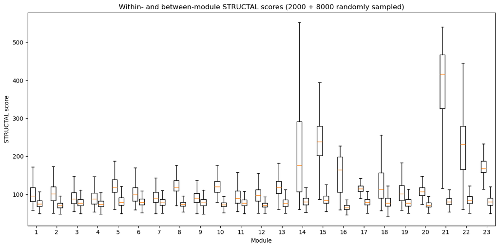

```python
# Statistical evaluation of pairwise STRUCTAL scores between and within modules
_summary_df, raw_scores = daliscope.analysis.structal_similarity.evaluate_module_cohesion(
    project, 'dom_FOLD', modules_df,
    n_within=2000, n_between=8000,
    modules=None,  # or None for everything, with the cost warning
)

# Box-plot
fig, ax = daliscope.analysis.communities.plot_module_score_distributions(
    raw_scores=raw_scores,
    figsize=(12, 6),
    title="Within- and between-module STRUCTAL scores (2000 + 8000 randomly sampled)",
)
```

# What structural and functional features characterize a population?

We demonstrate structural superimposition, domain architecture cartoons, and summaries of short functional descriptions.

## Transitive superimposition

Here we visualize examples from module 16, which is composed predominantly of germins (PF0100). The germins are structurally similar to one another, while also containing auxiliary structural elements and deletions relative to the Query.

The Query is a GOLD-like domain and is shown as a thin gray line, providing a reference for the structural comparisons.

Mouse controls: rotate, zoom, and pan.

```python
# Select view. Select targets by index.
view_name = 'dom_FOLD_module_16'
target_ixes = [11, 21, 31, 41, 51]

# Show multiple traces in py3Dmol
view = daliscope.widgets.pairwise_py3Dmol.generate_transitive_superimposition_view(
    target_ixes=target_ixes,
    df=project.views[view_name],
    project=project,
    target_ca_coords=project.coords,
    q_ca_coords=project.query_ca_coords,
    query_radius=0.15,
    show_query=True,
)
view.show()
```

[Query Scaffold] **Length:** 123 aa

[Target IX: 11] **ID:** tbtpA | **Align ID:** 6079 | **Z-score:** 4.80 | **RMSD:** 3.03 Å | **Len:** 76/123 | **SeqID:** 5.3%  
*MOLECULE: SPHERULIN-1B;*

[Target IX: 21] **ID:** cbmsA | **Align ID:** 6042 | **Z-score:** 4.50 | **RMSD:** 3.13 Å | **Len:** 77/123 | **SeqID:** 3.9%  
*ORYSJ:AF-Q6K5Q0-F1 PUTATIVE GERMIN-LIKE PROTEIN 2-1;*

[Target IX: 31] **ID:** biwiA | **Align ID:** 6049 | **Z-score:** 4.20 | **RMSD:** 3.19 Å | **Len:** 77/123 | **SeqID:** 6.5%  
*MAIZE:AF-B4FRS8-F1 GERMIN-LIKE PROTEIN;*

[Target IX: 41] **ID:** h072A | **Align ID:** 6060 | **Z-score:** 4.10 | **RMSD:** 3.14 Å | **Len:** 76/123 | **SeqID:** 6.6%  
*SOYBN:AF-I1K2Y1-F1 GERMIN-LIKE PROTEIN;*

[Target IX: 51] **ID:** th3xA | **Align ID:** 5994 | **Z-score:** 3.90 | **RMSD:** 2.50 Å | **Len:** 76/123 | **SeqID:** 5.3%  
*MOLECULE: GLUCOSE-6-PHOSPHATE ISOMERASE;*

3Dmol.js failed to load for some reason. Please check your browser console for error messages.

## Summarizing functional descriptions per module (t.b.i.)

# Summary of Workflow